# Intro to R

## Organization

1. Create an R Project (File/New Project). The home directory is the one where the .Rproj file is saved
2. Create a folder called Data where you store your Data, create a folder called ‘R’ where you store R scripts
3. Create an Rmarkdown (.Rmd) file to organize and annotate your analyses: File/New File/R Markdown. Save this in your home directory. Note you can view your Rmd file formatted in ‘visual’ style, similar to a MS Word document, or in Source format. The is toggled with a button in upper left corner
4. Determine which packages you will need and laod them in the first chunk of the Rmarkdown using library(). Commonly used packages include **dplyr** (for data management), **ggplot2** (for plotting), and **lubridate** (for handling date formatting)

## Chunks in R Markdown

RMarkdown files can be used to organize your code and to generate reproducible reports.

The code is organized in ‘chunks’

## Run Some code

If you want to run the code in a chunk, you can run the whole chunk by clicking the little green triangle at the top of the chunk; or to run a single line, put your cursor on the line and press CTRL+ENTER

```r
a1 <- 1+1
a1
```

```
## [1] 2
```

## Getting help

If you aren’t sure how a function works, you can find help documents in the panel at the right, or type ?function_name

```r
?readRDS
```

```
## starting httpd help server ... done
```

## Knitting

A nice feature of Rmarkdown files is they can generate reports in a variety of formats including html, pdf, .docx. Just click the ‘knit’ button at the top of the Rmd file to see the options.

## Read in data

We can use ‘relative paths’ when you are working in an Rproject. The home directory (denoted with a .) is where the .rproj file is. Here we refer to a file in the Data subdirectory. rds is an r data format

```r
d1 <- readRDS('./Data/mortality_1percent.rds')
```

You could save this as a .csv file if you need to export for other purposes

```r
write.csv(d1, './Data/mortality_1percent.csv')
```

You can even read in files directly from the web. For example, this reads in the csv file from Github. csv files are useful when moving data between programs (e.g., SAS to R)

```r
test1 <- read.csv('https://github.com/VA-CareDisruptions/IntroR_VA/blob/main/Data/mortality_1percent.csv?raw=true')
```

## Viewing your data

You can always view a spreadsheet with your data using ‘View()’

```r
View(d1)
```

Or if you just want a preview, use ‘head’

```r
head(d1)
```

```
## # A tibble: 6 x 26
##   month sex    year race_recode  agey icd1  icd2  icd3  icd4  icd5  icd6  icd7
##   <chr> <chr> <dbl>       <dbl> <dbl> <chr> <chr> <chr> <chr> <chr> <chr> <chr>
## 1 04    F      2019           1    91 A419  A419  <NA>  <NA>  <NA>  <NA>  <NA>
## 2 07    M      2014           2    63 I219  I219  <NA>  <NA>  <NA>  <NA>  <NA>
## 3 03    F      2015           1    83 I251  I620  I469  I251  E149  I10   E785
## 4 09    F      2020           1    72 J449  I461  J449  I500  I10   F179  <NA>
## 5 10    M      2016           1    72 C61   C61   <NA>  <NA>  <NA>  <NA>  <NA>
## 6 01    F      2020           1   106 G309  R64   G309  <NA>  <NA>  <NA>  <NA>
## # ... with 14 more variables: icd8 <chr>, icd9 <chr>, icd10 <chr>, icd11 <chr>,
## #   icd12 <chr>, icd13 <chr>, icd14 <chr>, icd15 <chr>, icd16 <lgl>,
## #   icd17 <lgl>, icd18 <lgl>, icd19 <lgl>, icd20 <lgl>, icd21 <lgl>
## # i Use `colnames()` to see all variable names
```

You can also extract info about number of rows and columns

```r
nrow(d1)
```

```
## [1] 200174
```

```r
ncol(d1)
```

```
## [1] 26
```

## Exploring your data

First, check the format of the variables in your data frame. ‘chr’ is a character variable, ‘num’ or’ int’ or ‘dbl’ are numeric variables; factor is a categorical variable.

```r
str(d1)
```

```
## tibble [200,174 x 26] (S3: tbl_df/tbl/data.frame)
##  $ month      : chr [1:200174] "04" "07" "03" "09" ...
##  $ sex        : chr [1:200174] "F" "M" "F" "F" ...
##  $ year       : num [1:200174] 2019 2014 2015 2020 2016 ...
##  $ race_recode: num [1:200174] 1 2 1 1 1 1 2 1 1 1 ...
##  $ agey       : num [1:200174] 91 63 83 72 72 106 69 59 90 59 ...
##  $ icd1       : chr [1:200174] "A419" "I219" "I251" "J449" ...
##  $ icd2       : chr [1:200174] "A419" "I219" "I620" "I461" ...
##  $ icd3       : chr [1:200174] NA NA "I469" "J449" ...
##  $ icd4       : chr [1:200174] NA NA "I251" "I500" ...
##  $ icd5       : chr [1:200174] NA NA "E149" "I10" ...
##  $ icd6       : chr [1:200174] NA NA "I10" "F179" ...
##  $ icd7       : chr [1:200174] NA NA "E785" NA ...
##  $ icd8       : chr [1:200174] NA NA NA NA ...
##  $ icd9       : chr [1:200174] NA NA NA NA ...
##  $ icd10      : chr [1:200174] NA NA NA NA ...
##  $ icd11      : chr [1:200174] NA NA NA NA ...
##  $ icd12      : chr [1:200174] NA NA NA NA ...
##  $ icd13      : chr [1:200174] NA NA NA NA ...
##  $ icd14      : chr [1:200174] NA NA NA NA ...
##  $ icd15      : chr [1:200174] NA NA NA NA ...
##  $ icd16      : logi [1:200174] NA NA NA NA NA NA ...
##  $ icd17      : logi [1:200174] NA NA NA NA NA NA ...
##  $ icd18      : logi [1:200174] NA NA NA NA NA NA ...
##  $ icd19      : logi [1:200174] NA NA NA NA NA NA ...
##  $ icd20      : logi [1:200174] NA NA NA NA NA NA ...
##  $ icd21      : logi [1:200174] NA NA NA NA NA NA ...
```

Let’s format a date variable using the month and year as inputs

Here we are going to use **pipes** to work with the data. a Pipe is denoted with a %>%. It is saying that we want to create a new data frame called ‘d2’. We are starting with data frame d1 and then adding onto it (mutating). We could also just overwrite d1 with the updated dataframe by writing d1 <- d1 %>%…

Creating dates is complicated. We first paste together the year and month columns from the data frame and append an ‘01’, separating each with a ‘-’. paste(year, month, ‘01’, sep=‘-’) This then has the format YYYY-MM-DD. But this is a character variable..we have to declare the variable as a Date and tell R what the format is as.Date(x, ‘%Y-%m-%d’)) %Y is 4 digit year (%y would be 2 digit year), %m is 2 digit month (%b would be 3 character month abbreviation), and %d for 2 digit day. This could all be done in a single step, but we will break it in 2 here

```r
d2 <- d1 %>%
  mutate( monthdate =paste(year, month, '01', sep='-'), monthdate = as.Date(monthdate) )
```

We can see here that the variable was created correctly

```r
str(d2)
```

```
## tibble [200,174 x 27] (S3: tbl_df/tbl/data.frame)
##  $ month      : chr [1:200174] "04" "07" "03" "09" ...
##  $ sex        : chr [1:200174] "F" "M" "F" "F" ...
##  $ year       : num [1:200174] 2019 2014 2015 2020 2016 ...
##  $ race_recode: num [1:200174] 1 2 1 1 1 1 2 1 1 1 ...
##  $ agey       : num [1:200174] 91 63 83 72 72 106 69 59 90 59 ...
##  $ icd1       : chr [1:200174] "A419" "I219" "I251" "J449" ...
##  $ icd2       : chr [1:200174] "A419" "I219" "I620" "I461" ...
##  $ icd3       : chr [1:200174] NA NA "I469" "J449" ...
##  $ icd4       : chr [1:200174] NA NA "I251" "I500" ...
##  $ icd5       : chr [1:200174] NA NA "E149" "I10" ...
##  $ icd6       : chr [1:200174] NA NA "I10" "F179" ...
##  $ icd7       : chr [1:200174] NA NA "E785" NA ...
##  $ icd8       : chr [1:200174] NA NA NA NA ...
##  $ icd9       : chr [1:200174] NA NA NA NA ...
##  $ icd10      : chr [1:200174] NA NA NA NA ...
##  $ icd11      : chr [1:200174] NA NA NA NA ...
##  $ icd12      : chr [1:200174] NA NA NA NA ...
##  $ icd13      : chr [1:200174] NA NA NA NA ...
##  $ icd14      : chr [1:200174] NA NA NA NA ...
##  $ icd15      : chr [1:200174] NA NA NA NA ...
##  $ icd16      : logi [1:200174] NA NA NA NA NA NA ...
##  $ icd17      : logi [1:200174] NA NA NA NA NA NA ...
##  $ icd18      : logi [1:200174] NA NA NA NA NA NA ...
##  $ icd19      : logi [1:200174] NA NA NA NA NA NA ...
##  $ icd20      : logi [1:200174] NA NA NA NA NA NA ...
##  $ icd21      : logi [1:200174] NA NA NA NA NA NA ...
##  $ monthdate  : Date[1:200174], format: "2019-04-01" "2014-07-01" ...
```

We can get some summary stats easily using the Table1 package

```r
table1(~agey + race_recode + sex, data=d2)
```

|  | Overall (N=200174) |
| --- | --- |
| agey |  |
| Mean (SD) | 80.7 (865) |
| Median [Min, Max] | 77.0 [0.00000190, 100000] |
| race_recode |  |
| Mean (SD) | 1.39 (0.856) |
| Median [Min, Max] | 1.00 [1.00, 5.00] |
| sex |  |
| F | 97574 (48.7%) |
| M | 102600 (51.3%) |

```r
d2 <- d1 %>%
  mutate(monthdate = as.Date(paste(year, month, '01', sep='-'), '%Y-%m-%d'), #format date as a date variable
         race_recode= factor(race_recode, levels=c(1,2,3,4,5), c('White','Black','Hispanic','American Indian', 'Asian/Pacific Islanders')) , #converts race to a factor
         sex= as.factor(sex), #define sex as a factor
         agey = if_else(agey>120,NA_real_, agey) #set age to missing if>120
         )
```

```r
table1(~agey + race_recode + sex, data=d2)
```

|  | Overall (N=200174) |
| --- | --- |
| agey |  |
| Mean (SD) | 73.1 (18.2) |
| Median [Min, Max] | 77.0 [0.00000190, 116] |
| Missing | 21 (0.0%) |
| race_recode |  |
| White | 154660 (77.3%) |
| Black | 24250 (12.1%) |
| Hispanic | 14776 (7.4%) |
| American Indian | 1376 (0.7%) |
| Asian/Pacific Islanders | 5112 (2.6%) |
| sex |  |
| F | 97574 (48.7%) |
| M | 102600 (51.3%) |

### Make some plots

ggplot can make pretty plots. The coding is modular. You add on a plot format or component with +

Here is a basic plot

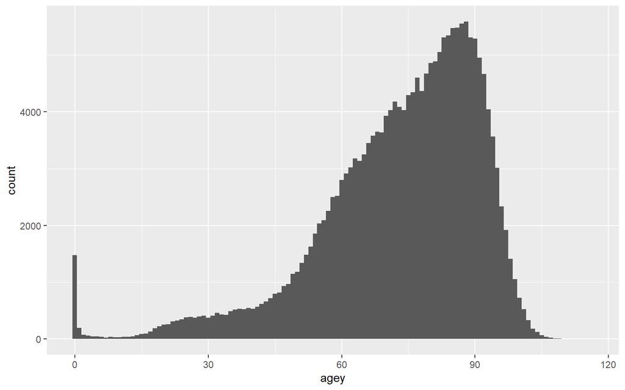

```r
ggplot(d2, aes(x=agey)) +
  geom_histogram(binwidth=1)
```

Make it look a little nicer

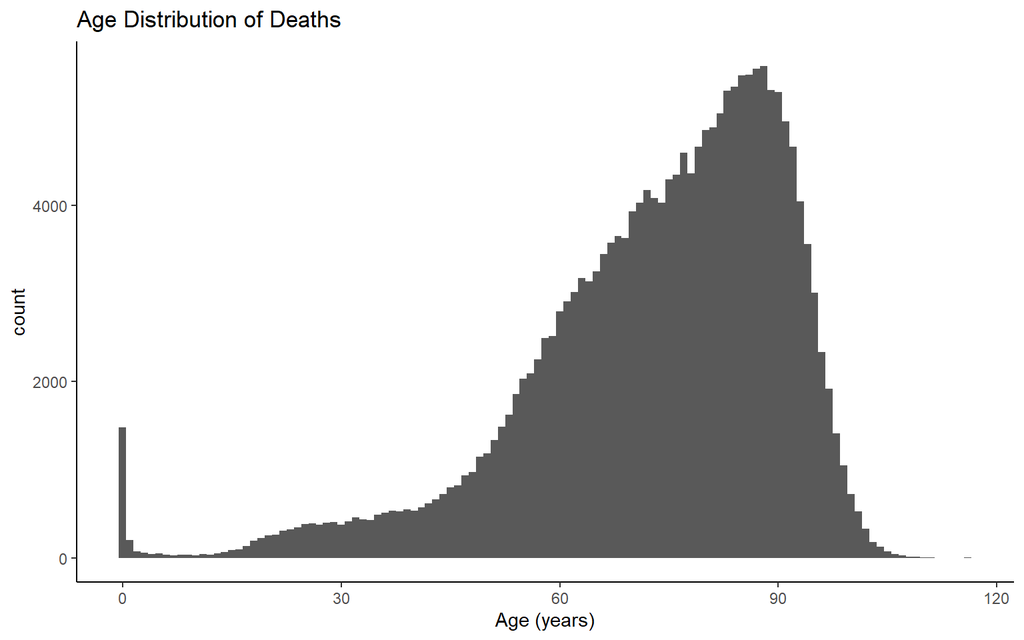

```r
ggplot(d2, aes(x=agey)) +
  geom_histogram(binwidth=1) +
  theme_classic()+ #makes it look pretty
    xlab('Age (years)')+ #x axis label
   ggtitle('Age Distribution of Deaths')
```

## Let’s create some time series

First let’s try all-cause deaths, by age group.

1. Create a variable denoting age category (agec)
2. Group the dataframe by agec and monthdate (group_by(agec, monthdate))
3. Count the number of rows in each group
4. Make sure all combinations of agec and monthdate are represented (filled time series)
5. Ungroup the dataset

```r
d3 <- d2 %>%
  mutate(agec = if_else( agey>=0 & agey<5,1,
                if_else(agey>=5 & agey<18,2,
                if_else(agey>=18 & agey<65,3,
                if_else(agey>=65 & agey<80,4,
                if_else(agey>=80 & agey<120,5,999
                            ))))),
         agec=as.factor(agec)
         ) %>%
  group_by(agec, monthdate) %>%
  summarize(N_deaths = n()) %>% # Step 3
  tidyr::complete(agec, monthdate, fill=list(N_deaths=0)) %>% # Step 4
  ungroup() %>%#Step 5
  filter(!is.na(agec)) %>% #if agec is missing, remove
   unique() #remove duplicate rows
```

[output not shown]

Check your work–we should have same number of rows per group

```r
d3 %>%
  group_by(agec) %>%
  summarize(N_dates=n())
```

```
## # A tibble: 5 x 2
##   agec  N_dates
##   <fct>   <int>
## 1 1          84
## 2 2          84
## 3 3          84
## 4 4          84
## 5 5          84
```

### Make some plots

This looks terrible…this is because we haven’t told R how to group the data

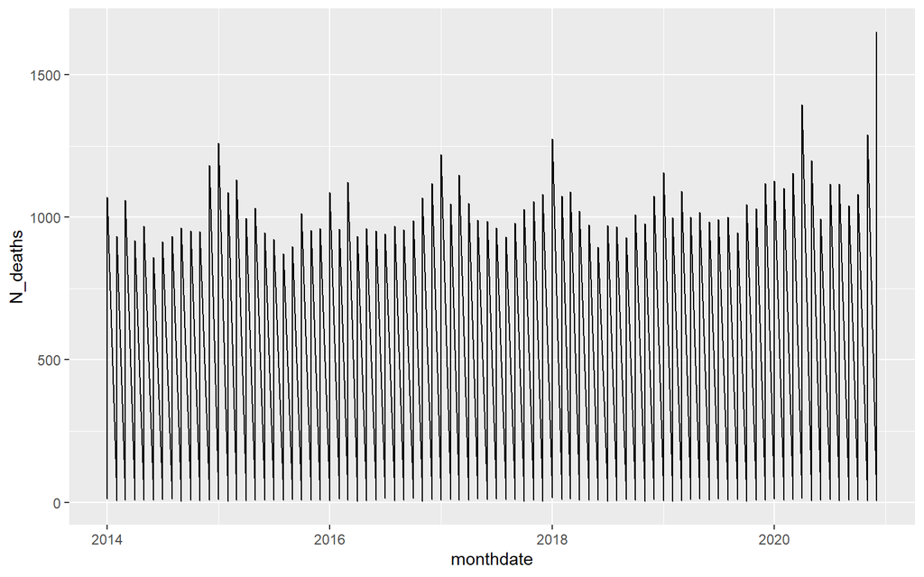

```r
ggplot(d3, aes(x=monthdate, y=N_deaths)) +
  geom_line()
```

That didn’t work because we didn’t tell ggplot that we have multiple observations per time point (by agec)

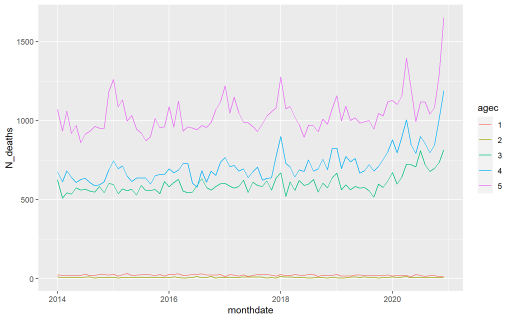

```r
ggplot(d3, aes(x=monthdate, y=N_deaths, group=agec, color=agec)) +
  geom_line()
```

Use a theme to make it look nicer

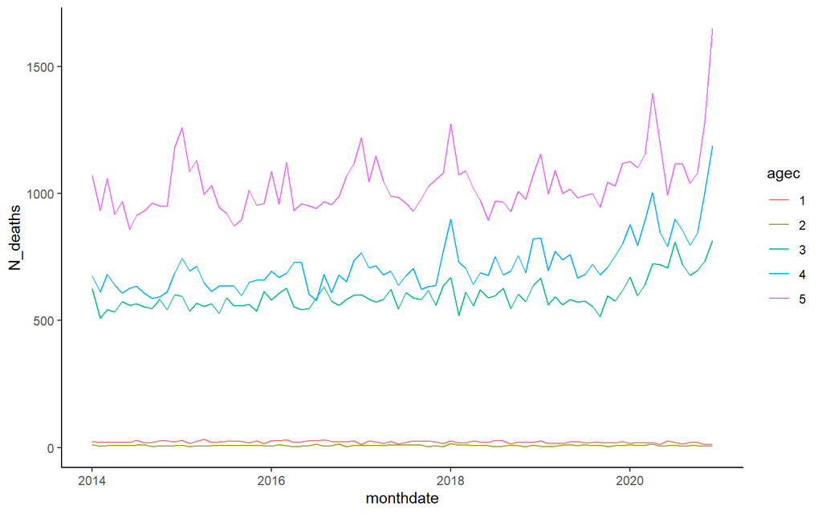

```r
ggplot(d3, aes(x=monthdate, y=N_deaths, group=agec, color=agec)) +
  geom_line() +
  theme_classic()
```

Facet wrap to separate out by column. ‘free_y’ allows each panel to have its own y axis

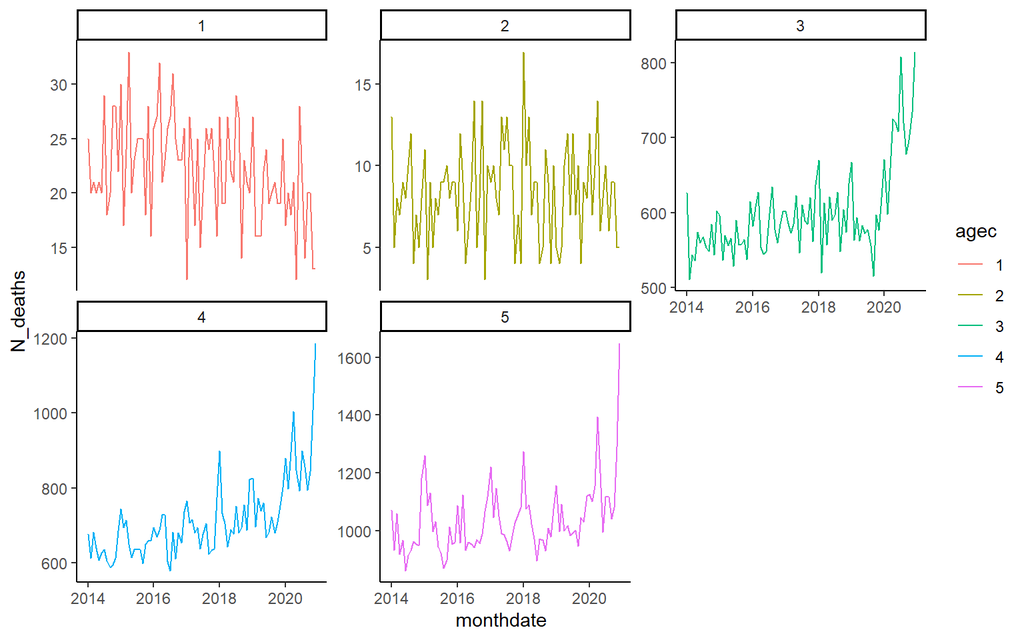

```r
ggplot(d3, aes(x=monthdate, y=N_deaths, group=agec, color=agec)) +
  geom_line() +
  theme_classic() +
  facet_wrap(~agec, scales='free_y')
```

To force the Y axis to 0, set ylim(0,NA), this means bottom must be 0, top goes to whatever max of the data is for that group.

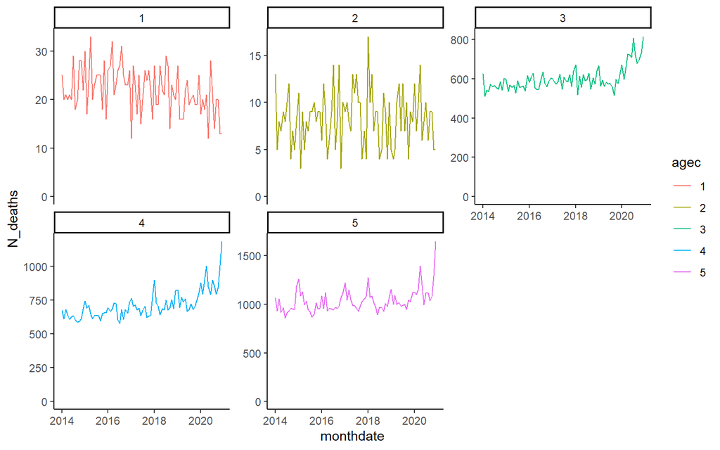

```r
ggplot(d3, aes(x=monthdate, y=N_deaths, group=agec, color=agec)) +
  geom_line() +
  theme_classic() +
  facet_wrap(~agec, scales='free_y')+
  ylim(0, NA)
```

## Working with vectors and matrices

In R you can work with individual numbers (ie calculate value of 1+1) with vectors of numbers (ie a variable), or with matrices. Data can also be stored in ‘data frames’ which is like a matrix but that can store a mix of numeric variables and character variables.

first let’s reshape our dataset to a wide format

‘melt the data’

```r
d3.m <- reshape2::melt(d3, id.vars=c('monthdate', 'agec'))
```

then ‘cast’ it, rows will be date, columns wil be agec

```r
d3.c <- reshape2::dcast(d3.m,monthdate~agec )
```

We can extract a column by position. We use matrix notation [row,column]. If you leave it empty, you take all

Here we will take the 5th column from d3.c, and all rows

```r
ag4 <- d3.c[,5]

ag4
```

```
##  [1]  676  613  682  640  608  627  636  606  588  594  613  686  745  694  714
## [16]  649  614  636  635  635  598  650  659  659  695  669  687  729  728  604
## [31]  578  682  610  681  653  737  766  707  716  680  694  637  676  705  624
## [46]  634  637  775  900  731  705  643  689  677  752  680  695  755  688  822
## [61]  826  696  772  739  761  667  682  723  681  709  754  802  879  797  896
## [76] 1005  847  792  899  856  795  844 1008 1187
```

Instead, just take the first 10 time points

```r
ag4.first.ten <- d3.c[1:10,5]
ag4.first.ten
```

```
##  [1] 676 613 682 640 608 627 636 606 588 594
```

You can add vectors together. Here we will add together the 4th and 5th columns, and combined together with column 4 and 5

```r
ag4_5 <- d3.c[,4] + d3.c[,5]

combined <- cbind.data.frame('ag4'=d3.c[,4], 'ag5'=d3.c[,5],ag4_5 )
```

or could do this with tidy coding:

```r
new_ds3 <- d3.c %>%
  rename(ag4 = `4`,
         ag5 = `5`) %>%
  mutate(ag4_5= ag4 + ag5)

new_ds3
```

```
##     monthdate  1  2   3  ag4  ag5 ag4_5
## 1  2014-01-01 25 13 626  676 1070  1746
## 2  2014-02-01 20  5 510  613  933  1546
## 3  2014-03-01 21  8 543  682 1059  1741
## 4  2014-04-01 20  7 535  640  919  1559
## 5  2014-05-01 21  9 574  608  968  1576
## 6  2014-06-01 20  8 559  627  860  1487
## 7  2014-07-01 29 10 567  636  915  1551
## 8  2014-08-01 18 12 553  606  933  1539
## 9  2014-09-01 20  4 548  588  962  1550
## 10 2014-10-01 28  7 584  594  952  1546
## 11 2014-11-01 28  5 543  613  949  1562
## 12 2014-12-01 22  8 602  686 1182  1868
## 13 2015-01-01 30 11 596  745 1260  2005
## 14 2015-02-01 17  3 536  694 1087  1781
```

[output cut: 70 more lines]

## Writing Functions

Anytime you find yourself coding the same thing over and over, you should consider writing a function to make it easier.

As a silly example, let’s provide the function with 2 numbers and add them together.

We will create a function call ‘my.fun1’. This function has 2 inputs ‘a’ and ‘b’. We will supply numeric values for a and b, which are added together and stored as ‘z’. Then it will return z

```r
my.fun1 <- function(a,b){
  z <- a + b
  return(z)
}
```

Now run the function. Change the input values of a and b and see what happens

```r
res1 <- my.fun1(a=1, b=1)
print(res1)
```

```
## [1] 2
```

Now try to add two vectors together (same function, but input vectors instead of single numbers (scalars))

```r
#Call the function
res1 <- my.fun1(a=new_ds3$ag4, b=new_ds3$ag5)
print(res1)
```

```
##  [1] 1746 1546 1741 1559 1576 1487 1551 1539 1550 1546 1562 1868 2005 1781 1846
## [16] 1645 1646 1581 1557 1506 1495 1664 1613 1619 1781 1627 1810 1662 1689 1556
## [31] 1519 1651 1566 1669 1720 1855 1986 1753 1864 1729 1683 1622 1639 1635 1604
## [46] 1661 1693 1855 2174 1806 1794 1665 1661 1572 1723 1647 1624 1764 1666 1897
## [61] 1983 1694 1863 1739 1779 1650 1674 1724 1627 1754 1784 1921 2005 1898 2051
## [76] 2399 2046 1786 2015 1972 1836 1925 2297 2836
```

Can also do this in a tidy workflow

```r
my.fun2 <- function(ds, xvar, yvar){
  z <- ds[,xvar] + ds[,yvar]
  return(z)
}
```

```r
new_ds3 %>%
  my.fun2(xvar='ag4', yvar='ag5')
```

```
##  [1] 1746 1546 1741 1559 1576 1487 1551 1539 1550 1546 1562 1868 2005 1781 1846
## [16] 1645 1646 1581 1557 1506 1495 1664 1613 1619 1781 1627 1810 1662 1689 1556
## [31] 1519 1651 1566 1669 1720 1855 1986 1753 1864 1729 1683 1622 1639 1635 1604
## [46] 1661 1693 1855 2174 1806 1794 1665 1661 1572 1723 1647 1624 1764 1666 1897
## [61] 1983 1694 1863 1739 1779 1650 1674 1724 1627 1754 1784 1921 2005 1898 2051
## [76] 2399 2046 1786 2015 1972 1836 1925 2297 2836
```

Or could make your plots in a function. we just take the code from above, but add a ‘filter’ by age function before we call ggplot (in a pipe)

```r
plot.fun1 <- function(age.select){
  d3 %>%
    filter(agec==age.select) %>%
  ggplot( aes(x=monthdate, y=N_deaths)) +
  geom_line() +
  theme_classic() +
  ylim(0, NA) +
    ggtitle(age.select)
}
```

Call the function to plot age group 1

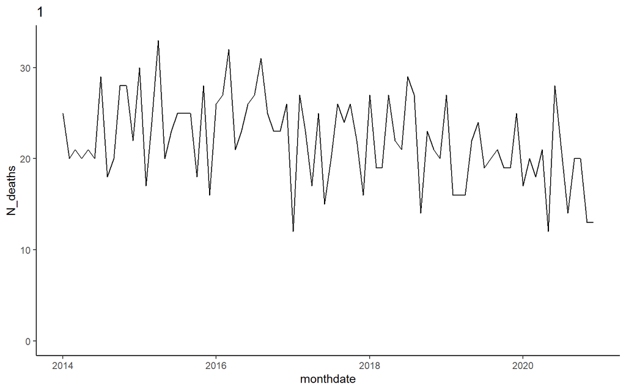

```r
plot.fun1(age.select='1')
```

Or age group 5

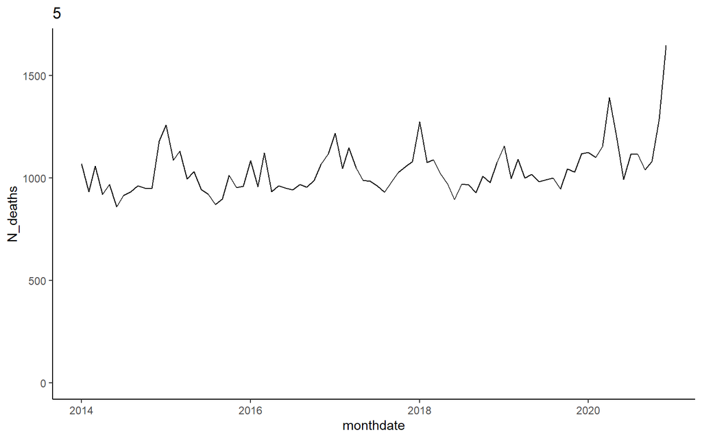

```r
plot.fun1(age.select='5')
```

[output not shown]